## Introduction to Lanscapemetrics

### Installing RTools

To install RTools, go to the website below and download the relevant version for your computer. Do not change any of the defaults, including the file path it is sent to.

Windows: https://cran.r-project.org/bin/windows/Rtools/rtools42/rtools.html  
mac: Run this in the command line `xcode-select --install` (note, I have not tried this)

### Bringing in a Raster file

First, we need to install the “terra” package. You will only need to install this package once. When we install packages, we generally want to do so from the console. Put each of these lines into the console below and run them

install.packages(“terra”)

Then, we need to bring in these packages. There are so many packages in r that it would be overly cumbersome to use all of them all at once. Thus each time you write a script, you’ll need to include the packages. This can be done as below:

```r
library(terra)
```

```r
# I inserted my working directory. For a file you want to do yourself you will need to include your own file path
data.tif <- rast("C:/ShrimpFarm/DaneCoNLCD2016.tif")
```

If we look at `data.tif`, we can see the raster attributes.

```r
data.tif
```

```
## class       : SpatRaster
## dimensions  : 1743, 2316, 1  (nrow, ncol, nlyr)
## resolution  : 29.98776, 29.99207  (x, y)
## extent      : 497820.5, 567272.1, 2222997, 2275273  (xmin, xmax, ymin, ymax)
## coord. ref. : Albers_Conical_Equal_Area
## source      : DaneCoNLCD2016.tif
## color table : 1
## categories  : Red, Green, Blue, NLCD_Land, Opacity
## name        : Red
## min value   :  70
## max value   : 108
```

We can also observe the data itself by running the block below (this will take a second)

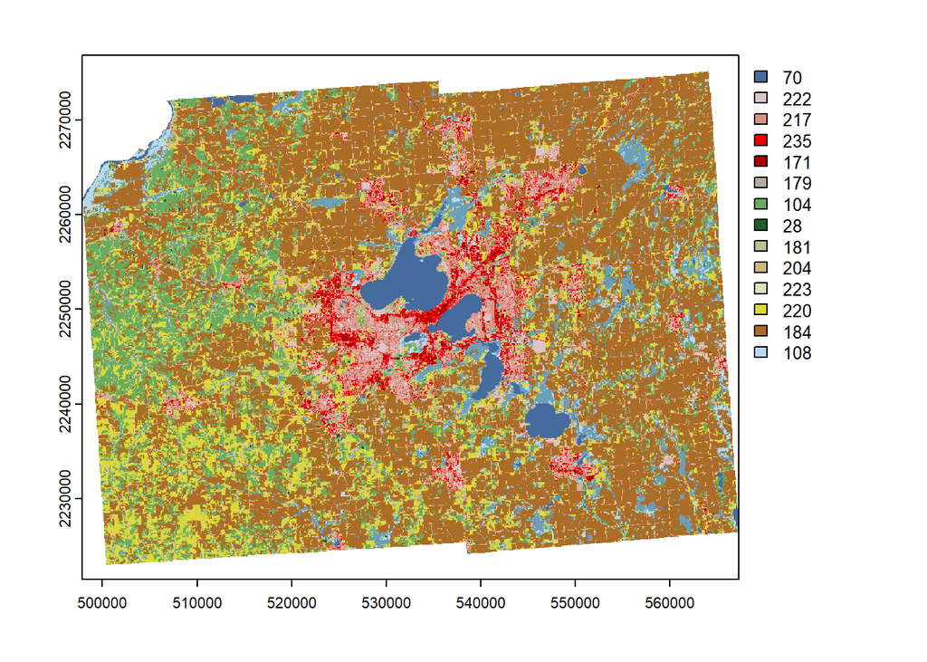

```r
plot(data.tif)
```

### Using Landscapemetrics

To use landscapemetrics, we will also need to install it and then call it. Put the line below into the console and run it. Then call the library by running the code block below.

install.packages(“landscapemetrics”)

Then we need to bring the package in so that we can use it:

```r
library(landscapemetrics)
```

The first thing we do when we want to use a file with landscapemetrics, is make sure that the file is usable with the package. The main error that comes about here is if your data isn’t metric.

```r
check_landscape(data.tif)
```

```
##   layer       crs units   class n_classes OK
## 1     1 projected     m integer        15  v
```

The below code blocks will collect the data for a number of variables. To get data from landscapemetrics, the majority of commands follow the following convention lsm_level_metric. Level is the unit you want to do, this can be 3 things: `p` for patch, `c` for class, and `l` for landscape. Metric is the value we want to calculate. For instance, we might be interested in the area of each patch. Then the command would be `lsm_p_area`.

Get the total number of patches:

```r
numpatches <- lsm_l_np(data.tif)
head(numpatches)
```

```
## # A tibble: 1 x 6
##   layer level     class    id metric  value
##   <int> <chr>     <int> <int> <chr>   <dbl>
## 1     1 landscape    NA    NA np     104144
```

Total number of patches in each land class

```r
patches.by.class <- lsm_c_np(data.tif)
head(patches.by.class)
```

```
## # A tibble: 6 x 6
##   layer level class    id metric value
##   <int> <chr> <int> <int> <chr>  <dbl>
## 1     1 class    11    NA np      1155
## 2     1 class    21    NA np     26147
## 3     1 class    22    NA np     22041
## 4     1 class    23    NA np     10644
## 5     1 class    24    NA np      3893
## 6     1 class    31    NA np       673
```

Total edge

```r
total.edge <- lsm_l_te(data.tif)
head(total.edge)
```

```
## # A tibble: 1 x 6
##   layer level     class    id metric     value
##   <int> <chr>     <int> <int> <chr>      <dbl>
## 1     1 landscape    NA    NA te     42630161.
```

Patch Areas

```r
patch.areas <- lsm_p_area(data.tif)
head(patch.areas)
```

```
## # A tibble: 6 x 6
##   layer level class    id metric   value
##   <int> <chr> <int> <int> <chr>    <dbl>
## 1     1 patch    11     1 area   88.5
## 2     1 patch    11     2 area    0.270
## 3     1 patch    11     3 area    0.360
## 4     1 patch    11     4 area    0.0899
## 5     1 patch    11     5 area    0.540
## 6     1 patch    11     6 area    0.0899
```

Proportion of Like Adjacency

```r
prop.like.adj <- lsm_l_pladj(data.tif)
head(prop.like.adj)
```

```
## # A tibble: 1 x 6
##   layer level     class    id metric value
##   <int> <chr>     <int> <int> <chr>  <dbl>
## 1     1 landscape    NA    NA pladj   80.1
```

### Exporting to Excel

We will now export our metrics to Excel for analysis. To export multiple dataframes to excel, we need the package openxlsx. We can install that by running the line below.

install.packages(“openxlsx”)

Then, we need to bring the package in so that we can use it:

```r
library(openxlsx)
```

We can put each dataframe we’ve made into a list, them insert that into `write.xlsx`. Running this like below will give you the sheet you need.

```r
list_of_datasets <- list("Total Number of Patches" = numpatches, "Patches by Class" = patches.by.class, "Total Edge"= total.edge, "Proportions of Like Adjacency"=prop.like.adj, "Patch Areas"=patch.areas)
write.xlsx(list_of_datasets, file = "LandscapMetricsData.xlsx")
```

Open your data file in Excel where you can describe and explore the results. Choose some metrics and create graphs to compare the results for each metric. Bar charts that compare 2001 and 2019 would be useful but so would others as well. You can use the Insert>Recommended Charts tool for ideas. Write a one-page write up describing your results and the metrics and how they indicate that this landscape has changed from 2001 to 2019? Has it become more or less fragmented? Make reference to your results in your description. Include graphs showing how any two of the class metrics changed between the 2 time periods. Add appropriate labels and titles.